# Special Works 3 Gauthier

## PROBLEM

A client would like to know the driving distance, in miles, between each pair of locations in a data table. Depending on the number of locations, that could be a LOT of pairs!

*BTW, have you heard this joke?:*

*Solve carefully: 230 -220 X 0.5 =*

*You probably won't believe it but the answer is 5!*

*(Source: KJ Cheetham @kj_cheetham)*

## DATA

[Location Data Provided by Client](https://wm-gis.maps.arcgis.com/home/item.html?id=9275188c73a74f09b898625373a5008a)

[Florida Roads Data Downloaded from Florida Department of Transportation](https://www.fdot.gov/statistics/gis/) Shapefile format

- [FDOT Roads Metadata](https://ftp.fdot.gov/file/d/FTP/FDOT/co/planning/transtat/gis/TRANSTAT_metadata/basemap_arcs.shp.xml)
- Note the Spatial Reference Information. Looking ahead, using Network Analysis tools to analyse local driving distances will require proper projections of the point locations and the network dataset:

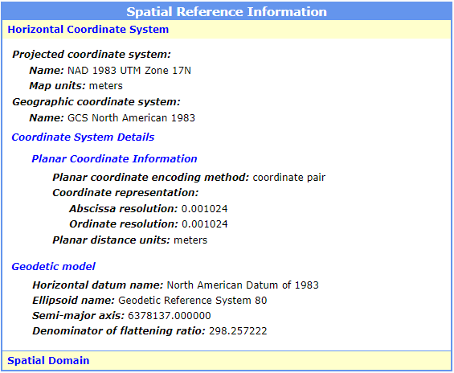

## TOOLS

### This project will utilize the [Network Analyst toolset in ArcGIS Pro](https://pro.arcgis.com/en/pro-app/tool-reference/network-analyst/an-overview-of-the-network-analyst-toolbox.htm).

The toolset includes Analysis, Network Dataset, and Turn Feature Class toolboxes.

[figure not shown]

> *Another possible option outside of ESRI would be to explore the v.net module in the [Geographic Resources Analysis Support System (GRASS)](https://grass.osgeo.org/grass78/manuals/v.net.html) which is easily accessible in QGIS.*

### Explore the Analysis toolbox:

[Show online](https://pro.arcgis.com/en/pro-app/tool-reference/network-analyst/an-overview-of-the-network-analysis-toolset.htm)

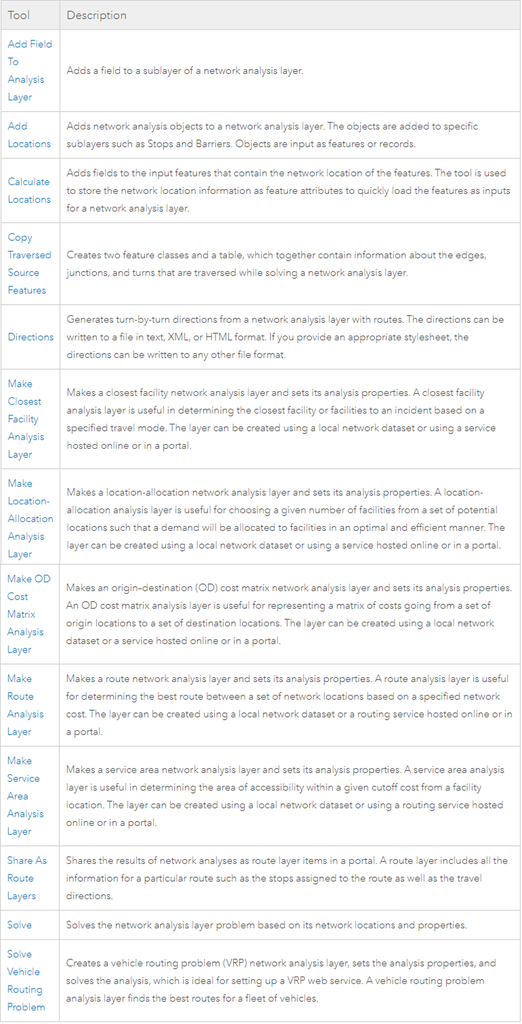

### Explore the Network Dataset toolbox:

[Show online](https://pro.arcgis.com/en/pro-app/tool-reference/network-analyst/an-overview-of-the-network-dataset-toolset.htm)

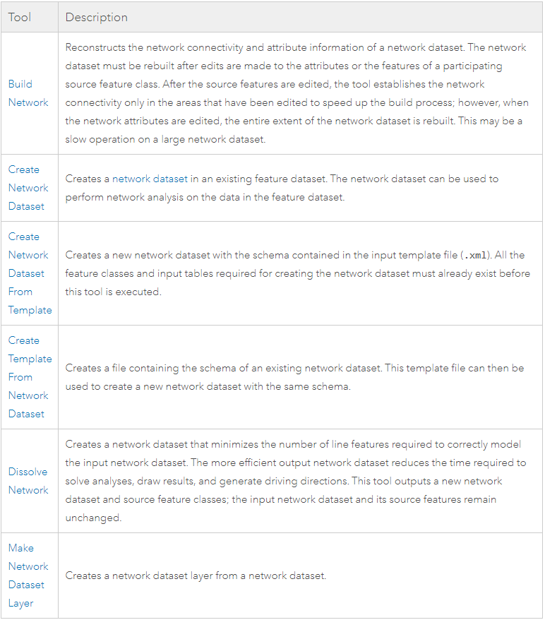

### To find the distance along roads (the network) between locations (origins and destinations), focus on the [Make OD Cost Matrix Analysis Layer tool](https://pro.arcgis.com/en/pro-app/tool-reference/network-analyst/make-od-cost-matrix-analysis-layer.htm) in the Analysis toolbox.

The description for this tool says, "The layer can be created using a local network dataset or a service hosted online or in a portal."

### To create a local network dataset, use the [Create Network Dataset](https://pro.arcgis.com/en/pro-app/tool-reference/network-analyst/create-network-dataset.htm) tool.

The description for this tool says, "Creates a network dataset in an existing feature dataset."

### To create an existing feature dataset, [use the Catalog or Create Feature Dataset](https://pro.arcgis.com/en/pro-app/tool-reference/data-management/create-feature-dataset.htm) tool.

The description for this tool says, "Creates a feature dataset in the output location—an existing enterprise or file geodatabase.)

### To create an existing file geodatabase, [use the Catalog, Create File Geodatabase tool, or CreateFileGDB_management function in Python](https://pro.arcgis.com/en/pro-app/help/data/geodatabases/overview/create-a-file-geodatabase.htm)

## GIS WORKFLOW

### Create a Feature Dataset and import the Florida roads shapefile

1. Open ArcGIS Pro with a new Folder for your project
2. In the Catalog, right-click on the folder and select New>File Geodatabase and Rename it.
3. In the Catalog, right-click on the new geodatabase and select New>Feature Dataset. This will open the Create Feature Dataset tool.
   - For Output Geodatabase, select the new geodatabase.
   - For Feature Dataset Name, type *Roads_FD*.
   - For Coordinate System *use Projected Coordinate System NAD 1983 UTM Zone 17N*. This is the native projection for the Florida roads data.

### Make a Locations Shapefile

1. In the Analysis tab, select Tools and search for the [Make XY Event Layer](https://pro.arcgis.com/en/pro-app/tool-reference/data-management/make-xy-event-layer.htm) tool. Open the tool.
   - For XY Table, browse to and select your client's location data.
   - The X Field and Y Field parameters should populate automatically.
   - For Layer Name, leave the default.
   - For Spatial Reference, leave th default.
1. Run the tool. A layer of Florida locations should appear on the map. This is a temporary layer file, not yet a shapefile, and it's not necessarily in the correct projection to work with the roads data.
2. In the Table of Contents pane, on the new layer, right-click>Data>Export Features. This opens the [Feature Class to Feature Class](https://pro.arcgis.com/en/pro-app/tool-reference/data-management/make-xy-event-layer.htm) tool. This will convert the event layer into a shapefile.
   - For Input Features, use the drop-down to select your new event layer
   - For Output Location, use the default
   - For Output Feature Class, use the default
1. Run the tool.

### Project the Locations Shapefile

1. Search for and open the [Project](https://pro.arcgis.com/en/pro-app/tool-reference/data-management/project.htm) tool.
   - For Input Dataset or Feature Class use the new shapefile
   - For Output Dataset or Feature Class, browse to the Roads_FD and name the file Locations.
   - For Output Coordinate System *use Projected Coordinate System NAD 1983 UTM Zone 17N*.

### Complete the Feature Dataset

1. In the Catalog, copy the Florida roads shapefile into Roads_FD and rename the shapefile Roads

### Create and Build the Network Dataset

1. Open the [Create Network Dataset](https://pro.arcgis.com/en/pro-app/tool-reference/network-analyst/create-network-dataset.htm) tool.
   - For Target Feature Dataset select Roads_FD
   - For Network Dataset Name type *Roads_ND*.
   - For Source Feature Classes, check Roads.
1. Run the tool, then remove the Roads_ND layer from the Table of Contents.
2. In the Catalog, right-click Roads_ND>Properties. For Travel Attributes, in the Costs Tab, change the units for Length to miles. OK.
1. Open the [Build Network](https://pro.arcgis.com/en/pro-app/tool-reference/network-analyst/build-network.htm) tool.
   - For Input Network Dataset select Roads_ND.
1. Run the tool.

### Run the OD Cost Matrix Analysis

1. In the Analysis tab, select Network Analysis and choose Origin-Destination Cost Matrix to run the tool.

[figure not shown]

- A set of empty Layers will appear that need data imported into them, and a new tab for the tool appears in purple on the top ribbon.
- In the Network Analyst OD Cost Matrix tab, Select Import Origins. The [Add Locations](https://pro.arcgis.com/en/pro-app/tool-reference/network-analyst/add-locations.htm) tool opens.
  - For Input Network Analysis Layer, select OD Cost Matrix.
  - For Sub Layer, select Origins
  - For Input Locations, select Locations.
  - Uncheck Append to Existing Locations.
- In the Network Analyst OD Cost Matrix tab, Select Import Destinations. The [Add Locations](https://pro.arcgis.com/en/pro-app/tool-reference/network-analyst/add-locations.htm) tool opens.
  - For Input Network Analysis Layer, select OD Cost Matrix.
  - For Sub Layer, select Destinations
  - For Input Locations, select Locations.
  - Uncheck Append to Existing Locations.
1. In the Network Analyst OD Cost Matrix tab, select Run. This will run the [Solve](https://pro.arcgis.com/en/pro-app/tool-reference/network-analyst/solve.htm) tool on the OD Cost Matrix Layer.

### Export the Lines Table

1. In the OD Cost Matrix group, for the Lines layer, right-click>Open Attribute Table. There should be 5,476 pairs of locations analyzed. The table shows the origin and destination ID number, ranked by shortest distance first, and the driving distance, in miles, under Total_Length.
2. In the Table tab (View), select Export Table. This opens the [Copy Rows](https://pro.arcgis.com/en/pro-app/tool-reference/data-management/copy-rows.htm) tool, which exports the table as "a new geodatabase, .csv, .txt, or .dbf table".
   - For Input Rows, select the Lines table.
   - For Output Table, save the table in any location. Include the extention .csv, .txt., or .dbf in the name.

## RESULTS

[Download Data Table](https://wm-gis.maps.arcgis.com/sharing/rest/content/items/00ce32a09601432f9f77383cdd5ff93d/data)